# R Notebook - Lab 3 - CP 1

#### 1) Descrição da Atividade

De fato, os dados de acesso a projetos da wikimedia que utilizamos no problema 2 são dados de uma amostra dos usuários, e não da população.

Sabendo disso, produza uma versão resumida do relatório que você fez para o Lab 2, CP 4, que:

1. responde as 3 primeiras perguntas da tarefa original utilizando inferência estatística realizada através de intervalos de confiança e bootstrap.
2. testa o que acontece se para a pergunta 1, em vez de comparar o grupo A com o grupo B (um teste A/B), você compara metade das sessões do grupo A (escolhida aleatoriamente) com outra metade das sessões do mesmo grupo (um teste A/A).

Ressalte em seu relatório a conclusão possível sobre a população que você está fazendo a partir da inferência. Lembre de escrever uma frase com o vocabulário do domínio do problema explicando seu achado, e de formalizá-la em nível de confiança. Comente tanto significância (estatística) quanto relevância prática de diferenças que você venha a encontrar.

#### 2) Bibliotecas e Dados

```r
library(tidyverse)
library(here)
library(lubridate)
```

```r
library(ggplot2)
library(boot)
```

As variáveis utilizadas serão:

1. **session_id**: Identificador exclusivo de cada sessão
2. **search_index**: Quantidade de buscas em uma mesma sessão
3. **session_duracao**: Duração de cada sessão em segundos
4. **session_data**: Data da sessão no formato ano-mes-dia
5. **session_start_time**: Timestamp inicial da sessão
6. **session_start_date**: Data e hora do início da sessão
7. **group**: Rótulo para dividir em grupo a ou grupo b
8. **results**: Quantidade de resultados de uma busca
9. **num_clicks**: Quantidade de páginas abertas pelo usuário
10. **first_click**: posição da página visitada

Uma observação a ser feita, que este dataset foi gerado atráves da função head(100000) do arquivo original, sendo assim, não estão inclusos todos os dados, caso perceba-se alguma diferença nos dados aqui utilizados.

```r
projeto = read_csv(here::here("/data/search_data3.csv"))
select(projeto, session_id, search_index, session_duracao, session_data, session_start_timestamp, session_start_date, group, results, num_clicks, first_click)
```

| session_id | search_index | session_duracao | session_data | session_start_timestamp | session_start_date | group | results | num_clicks | first_click |
| --- | --- | --- | --- | --- | --- | --- | --- | --- | --- |
| 61e6cb95570e935e | 1 | 14 | 2016-03-01 | 2.01603e+13 | 2016-03-01 00:00:09 | a | 20 | 1 | 2 |
| 0b2a585b930522c1 | 1 | 0 | 2016-03-01 | 2.01603e+13 | 2016-03-01 00:00:19 | b | 20 | 0 | NA |
| 7f138b9eab3d2e29 | 1 | 0 | 2016-03-01 | 2.01603e+13 | 2016-03-01 00:00:38 | b | 0 | 0 | NA |
| 61407b4a072dc6f6 | 1 | 1131 | 2016-03-01 | 2.01603e+13 | 2016-03-01 00:00:40 | a | 0 | 0 | NA |
| 7937c525a619e744 | 1 | 2 | 2016-03-01 | 2.01603e+13 | 2016-03-01 00:00:40 | a | 1 | 0 | NA |
| 23ca1f966a29d591 | 1 | 299 | 2016-03-01 | 2.01603e+13 | 2016-03-01 00:00:42 | a | 20 | 1 | 10 |
| 7937c525a619e744 | 2 | 2 | 2016-03-01 | 2.01603e+13 | 2016-03-01 00:00:42 | a | 0 | 0 | NA |
| 61407b4a072dc6f6 | 2 | 1131 | 2016-03-01 | 2.01603e+13 | 2016-03-01 00:01:20 | a | 0 | 0 | NA |
| 88c9e1dea8d07dff | 1 | 0 | 2016-03-01 | 2.01603e+13 | 2016-03-01 00:01:20 | b | 20 | 0 | NA |
| 23ca1f966a29d591 | 2 | 299 | 2016-03-01 | 2.01603e+13 | 2016-03-01 00:01:56 | a | 20 | 1 | 11 |

[output cut: 9990 more lines]

#### 3) Analisando os dados

É notório que o grupo A realizou possui mais sessões realizadas que o grupo B, tendo o grupo A um tamanho duas vezes maior que o grupo B.

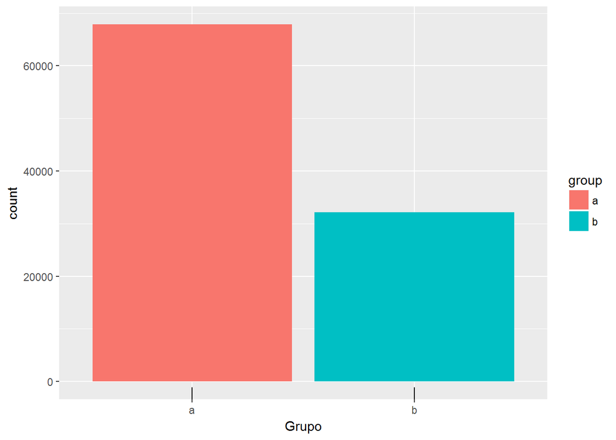

```r
projeto %>%
    ggplot(aes(x = group, fill = group)) +
    geom_bar() +
    geom_rug() +
    labs(xlab("Grupo"), ylab("Quantidade de buscas realizadas"))
```

Em relação aos dias da semana, tanto o grupo A, como o grupo B, seguiram uma tendência muito parecida. O número de sessões foi crescendo nos três primeiros dias (01 de março à 03 de março). Nos dias 04 e 05 de Março, houve uma tendência decrescente na quantidade de sessões, mas logo em seguida, nos dias 06 e 07, houve novamente uma crescente nas sessões. Que por fim, decresceram novamente no último dia.

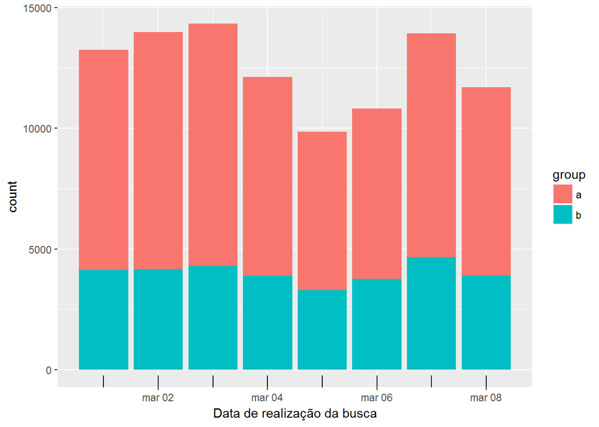

```r
projeto %>%
    ggplot(aes(x = session_data, fill = group)) +
    geom_bar() +
    geom_rug() +
    labs(xlab("Data de realização da busca"), ylab("Quantidade de buscas realizadas"))
```

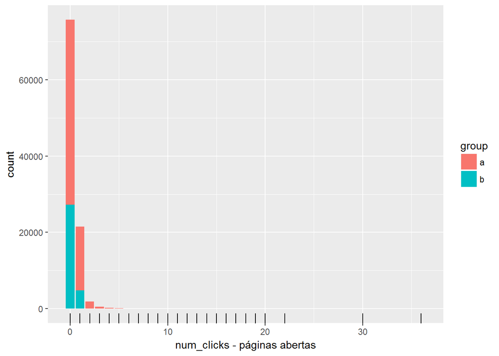

```r
projeto %>%
    ggplot(aes(x = num_clicks, fill = group)) +
    geom_bar() +
    geom_rug() +
    labs(xlab("num_clicks - páginas abertas"), ylab("quantidade"))
```

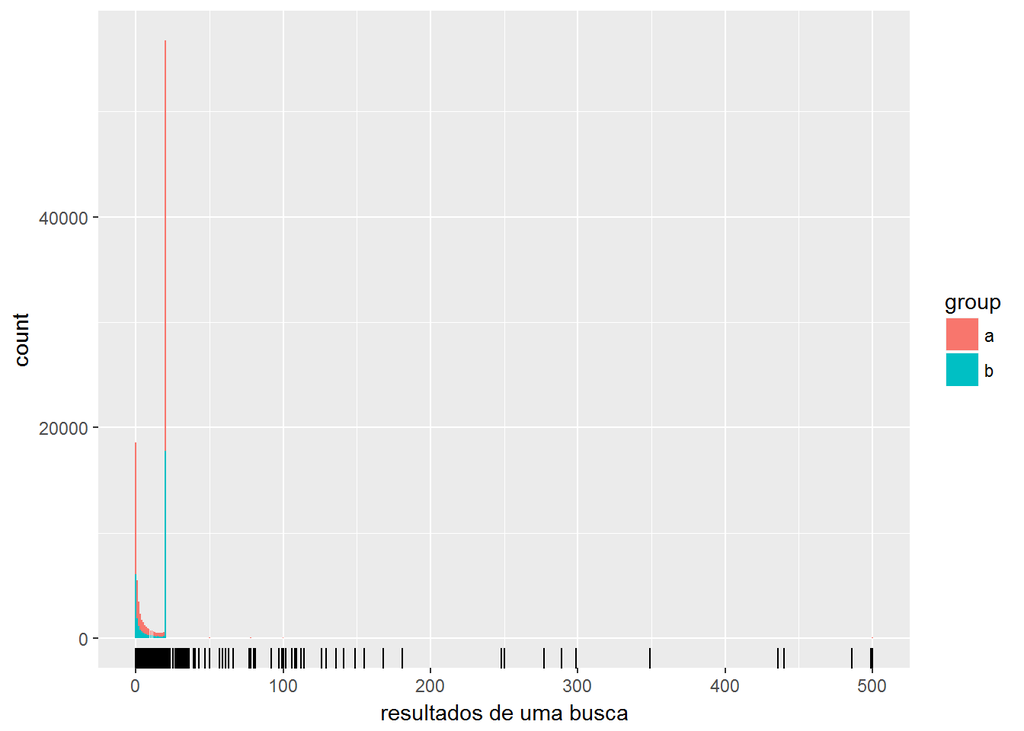

```r
projeto %>%
    ggplot(aes(x = results, fill = group)) +
    geom_bar() +
    geom_rug() +
    labs(xlab("resultados de uma busca"), ylab("Quantidade"))
```

#### 4) Perguntas do Relatório

1. responde as 3 primeiras perguntas da tarefa original utilizando inferência estatística realizada através de intervalos de confiança e bootstrap.
2. testa o que acontece se para a pergunta 1, em vez de comparar o grupo A com o grupo B (um teste A/B), você compara metade das sessões do grupo A (escolhida aleatoriamente) com outra metade das sessões do mesmo grupo (um teste A/A).

##### 4.1) Qual é a nossa taxa de cliques geral diária? Como isso varia entre os grupos?

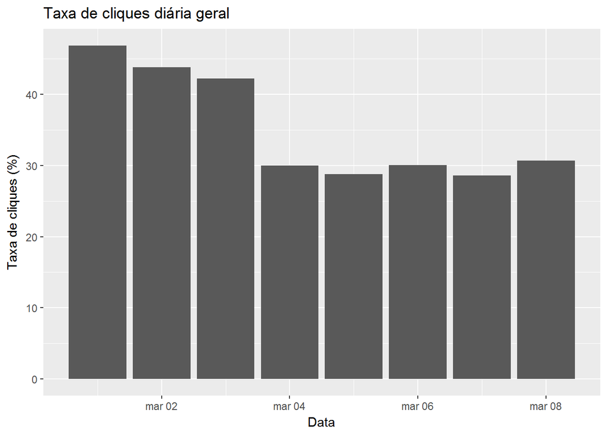

```r
total_buscas = projeto %>%
    group_by(session_data, group) %>%
    summarise(n = n(), taxa_num_clicks = ((sum(num_clicks))/n)*100)

total_buscas%>%
    ggplot(aes(x = session_data, y = taxa_num_clicks)) +
    geom_col(position = "dodge") +
    labs(title="Taxa de cliques diária geral",
         x="Data",
         y="Taxa de cliques (%)")
```

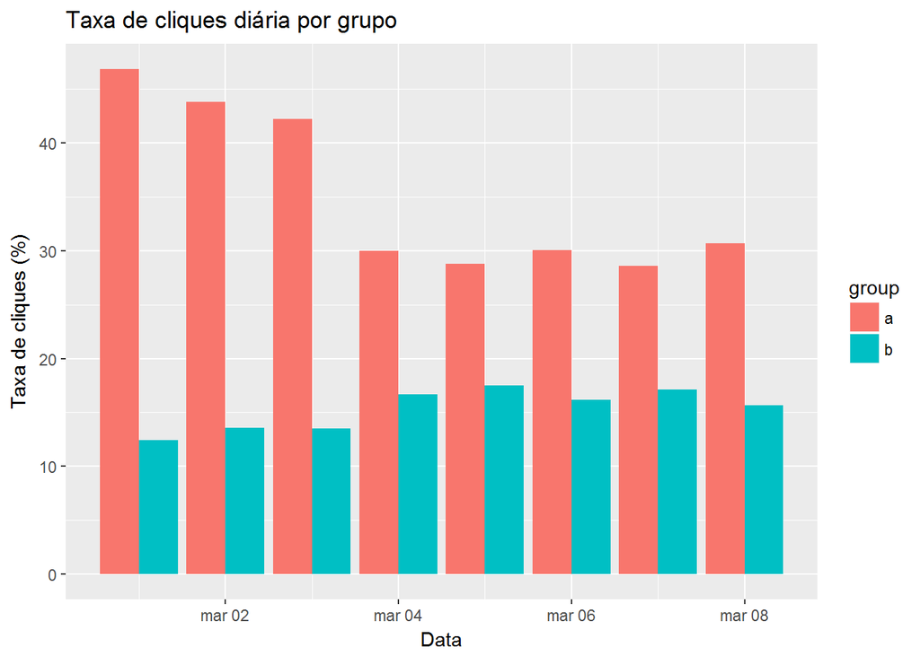

```r
total_buscas%>%
    ggplot(aes(x = session_data, y = taxa_num_clicks, fill = group)) +
    geom_col(position = "dodge") +
    labs(title="Taxa de cliques diária por grupo",
         x="Data",
         y="Taxa de cliques (%)")
```

```r
funcao_num_clicks <- function(dados, indices) {
    mean_num_clicks <- dados %>%
        slice(indices) %>%
        group_by(session_data) %>%
        summarise( n = n(), taxa_num_clicks = (sum(num_clicks)/n)*100) %>%
        pull(taxa_num_clicks) %>%
        mean()
    return(mean_num_clicks)
}

bootstrap_num_clicks <- boot(data = projeto, statistic = funcao_num_clicks, R = 2000)

boot.ci(boot.out = bootstrap_num_clicks, conf = 0.95, type = "basic")
```

```
## BOOTSTRAP CONFIDENCE INTERVAL CALCULATIONS
## Based on 2000 bootstrap replicates
##
## CALL :
## boot.ci(boot.out = bootstrap_num_clicks, conf = 0.95, type = "basic")
##
## Intervals :
## Level      Basic
## 95%   (28.48, 29.24 )
## Calculations and Intervals on Original Scale
```

##### 4.2) Quais resultados as pessoas tendem a tentar primeiro? Como isso muda no dia-a-dia?

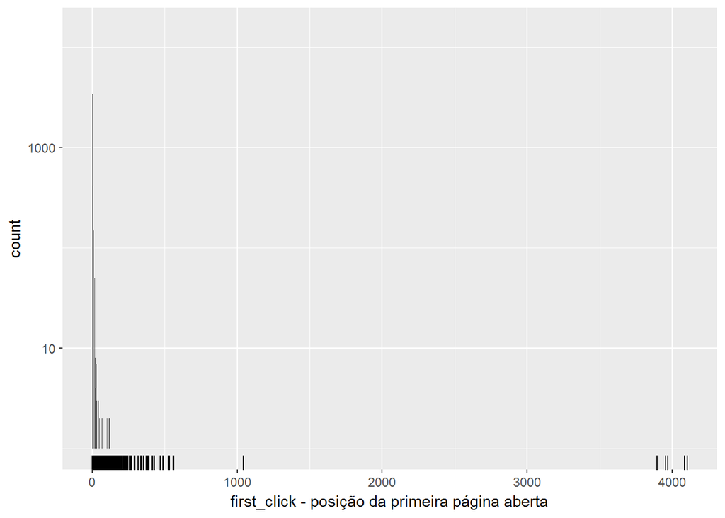

```r
projeto %>%
    ggplot(aes(x = first_click)) +
    geom_bar() +
    geom_rug() +
    labs(xlab("first_click - posição da primeira página aberta"), ylab("Quantidade")) +
    scale_y_log10()
```

```r
funcao_first_click <- function(dados, indices) {
    mean_first_click <- dados %>%
        filter(!is.na(first_click)) %>%
        slice(indices) %>%
        pull(first_click) %>%
        mean()

    return(mean_first_click)
}

bootstrap_first_click <- boot(data = projeto, statistic = funcao_first_click, R = 2000)

boot.ci(boot.out = bootstrap_first_click, conf = 0.95, type = "basic")
```

```
## BOOTSTRAP CONFIDENCE INTERVAL CALCULATIONS
## Based on 2000 bootstrap replicates
##
## CALL :
## boot.ci(boot.out = bootstrap_first_click, conf = 0.95, type = "basic")
##
## Intervals :
## Level      Basic
## 95%   ( 3.409,  4.948 )
## Calculations and Intervals on Original Scale
```

Com isso, podemos concluir, com 95% de confiança, que a posição da primeira página clicada está entre 3 e 5.

##### 4.3) Qual é a nossa taxa de resultados zero no geral? Como isso varia entre os grupos?

A taxa de resultados iguais a zero, em ambos os grupos está próximo de 18% e 19%, sendo o grupo B o que mais contém resultados iguais a zero, sendo a diferença para o grupo A extremamente pequena.

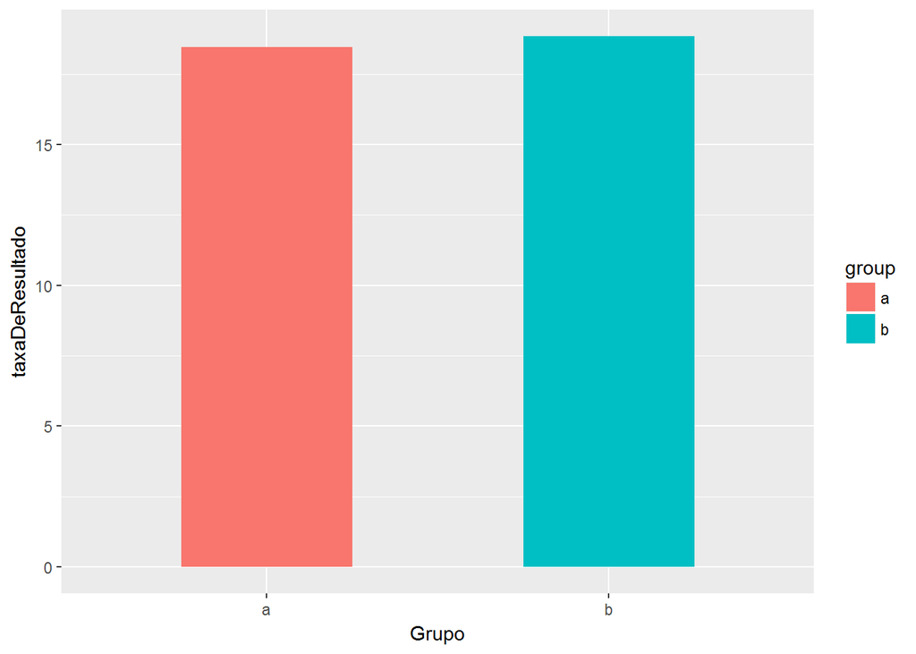

```r
total_results_porGrupo = projeto %>%
    group_by(group, results) %>%
    summarise(n = n()) %>%
    mutate(taxaDeResultado = n / sum(n) * 100)

total_results_porGrupo %>%
    filter(results == 0) %>%
    ggplot(aes(x = group, y = taxaDeResultado, fill = group)) +
    geom_col(width = .5) +
    labs(xlab("Grupo"), ylab("Taxa de resultados iguais a zero (%)"))
```

```r
funcao_results_zero <- function(dados, indices) {
    taxa_results_zero <- dados %>%
        slice(indices) %>%
        group_by(group, results) %>%
        summarise(n = n()) %>%
        mutate(taxaDeResultado = n / sum(n) * 100) %>%
        filter(results == 0) %>%
        pull(taxaDeResultado)

    return(taxa_results_zero)
}

bootstrap_results_zero <- boot(data = projeto, statistic = funcao_results_zero, R = 2000)

boot.ci(boot.out = bootstrap_results_zero, conf = 0.95, type = "basic")
```

```
## BOOTSTRAP CONFIDENCE INTERVAL CALCULATIONS
## Based on 2000 bootstrap replicates
##
## CALL :
## boot.ci(boot.out = bootstrap_results_zero, conf = 0.95, type = "basic")
##
## Intervals :
## Level      Basic
## 95%   (18.16, 18.74 )
## Calculations and Intervals on Original Scale
```

#### testa o que acontece se para a pergunta 1, em vez de comparar o grupo A com o grupo B (um teste A/B), você compara metade das sessões do grupo A (escolhida aleatoriamente) com outra metade das sessões do mesmo grupo (um teste A/A).

```r
grupoA = projeto %>%
    filter(group == "a")

amostra1_grupoA = sample_n(grupoA, nrow(grupoA)/2)
amostra2_grupoA = sample_n(grupoA, nrow(grupoA)/2)

amostra_grupoA = bind_rows(amostra1_grupoA, amostra2_grupoA)

funcao_num_clicks <- function(dados, indices) {
    mean_num_clicks <- dados %>%
        slice(indices) %>%
        group_by(session_data) %>%
        summarise( n = n(), taxa = (sum(num_clicks)/n)*100) %>%
        pull(taxa) %>%
        mean()
    return(mean_num_clicks)
}

bootstrap_num_clicks <- boot(data = amostra_grupoA, statistic = funcao_num_clicks, R = 2000)

boot.ci(boot.out = bootstrap_num_clicks, conf = 0.95, type = "basic")
```

```
## BOOTSTRAP CONFIDENCE INTERVAL CALCULATIONS
## Based on 2000 bootstrap replicates
##
## CALL :
## boot.ci(boot.out = bootstrap_num_clicks, conf = 0.95, type = "basic")
##
## Intervals :
## Level      Basic
## 95%   (34.46, 35.53 )
## Calculations and Intervals on Original Scale
```